# KD Practicum 1.2

## Atomic vectors

Vectors are the most important data structures in R. Like vectors in physics, we might think of a vector as something that has a magnitude and a direction, and that can be represented by a sequence of numbers. In its notion of a vector, R keeps the idea of a sequence but discards magnitude and direction.

For R, a vector is simply a sequence of elements. Vectors can exist in two basic forms:

|  | Homogeneous | Heterogeneous |
| --- | --- | --- |
| 1D | Atomic vector | Recursive vector (List) |
| 2D | Matrix | Data frame (List, Tibble) |
| Multidimensional | Array |  |

There are four primary types of atomic vectors: *logical*, *integer*, *double*, and *character* (which contains strings). Collectively, integer and double vectors are known as *numeric* vectors. Examples of each vector type are listed below:

- **character:** `"a"` , `"swc"`
- **numeric:** `2` , `15.5`
- **integer:** `2L` (the `L` tells R to store this as an integer)
- **logical:** `TRUE` , `FALSE`
- **complex:** `1+4i` (complex numbers with real and imaginary parts)

### Numeric vectors

The general pattern for vector initialization is `vector(mode, length)`. You can also create vectors by

- concatenating different elements with function `c()` , or
- by creating a sequence using the sequence operator `:`, i.e. `1:10`.
- Alternatively, you can benefit from functions such as `rep()`, which repeats a given sequence of number n times and `sample()`, which generates a sequence of randomly picked numbers from a given statistical distribution.

Let’s create a numeric vector object that will be accessible by name *x*. Note that the association `<-` is the same as `=` in Python.

```r
# Create an empty vector with size of 2.
integer(2)
```

```
## [1] 0 0
```

```r
# Create a sequence of numbers from 1 to 3.
1:3
```

```
## [1] 1 2 3
```

```r
# Create a new vector by repeating 1 three times.
rep(1,3)
```

```
## [1] 1 1 1
```

```r
# Create a new vector from 3 randomly-sampled integers.
sample(rnorm(3, mean = 10, sd = 2))
```

```
## [1]  9.999353 10.464523 11.590148
```

```r
# Coerce three numeric vectors of length 1 into a single vector named x.
x <- c(1, 2, 3)
# Print the content of x.
x
```

```
## [1] 1 2 3
```

### Logical and character vectors

In a similar vein, we can create **logical vector** `y <- c(TRUE, TRUE, FALSE, FALSE)` and **character vectors** `z <- c("Alec", "Dan", "Rob", "Rich")` using the left association operator.

Numeric, logical and character vectors constitute the most common vector types in R, implying the following type hierarchy.

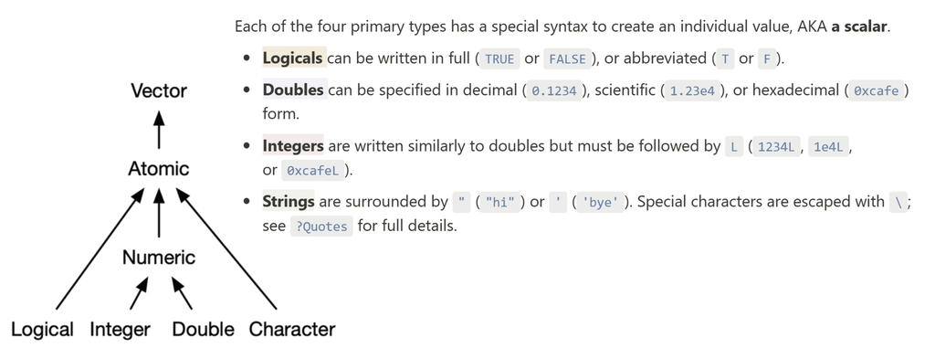

Regardles of type, every vector has common properties, which can be examined with tools provided by R. For example, we can ask about:

- `class()` - tells us about the class of an object. (high level)
- `typeof()` - tells us about the object’s type. (low level)
- `length()` - tells us about how many elements does the object have.
- `attributes()` - tells us whether the object does have any attached metadata,

```r
# Print the class, type and length attribute(s) of vector x.
class(x) ; typeof(x) ; length(x)
```

```
## [1] "numeric"
```

```
## [1] "double"
```

```
## [1] 3
```

### Factors

Factors are a special type of vector containing only predefined values. They are used to store categorical data. Factors are built on top of integer vectors by enumerating factor levels, which defines the set of allowed values.

```r
f <- factor(c("a", "b", "b", "a")) ; f
```

```
## [1] a b b a
## Levels: a b
```

```r
levels(f) # Print levels (aka unique categories) of f.
```

```
## [1] "a" "b"
```

Factors are useful when we know the set of possible values but they’re not all present in a given dataset. In contrast to the character vector, when a factor is tabulated (`table()`) we will get counts of all categories, even unobserved ones.

**Ordered factors** constitute a minor variation of factor type. They behave like regular factors, but the order of the levels is meaningful (low, medium, high) and is often leveraged in data modelling and data visualization.

```r
ordered(c("b", "b", "a", "c"), levels = c("c", "b", "a"))
```

```
## [1] b b a c
## Levels: c < b < a
```

## Data manipulations using vectors

### Vector arithmetics

Vectors are one part of a story, but the real power comes from R supporting **vectorized operations**. This is a deep piece of engineering in the design, but most of R will think quite happily in terms of vectors. For example, if you want to double all values of `x`, all that’s needed is to type this:

```r
# Multiply each element of vector x by 2.
2 * x
```

```
## [1] 2 4 6
```

You can also add scalars, get the maximum and minimum values and so on. Note that **`;`** separates multiple commands in the same line so you can save some space.

```r
# Print mean, minimum and maximum of x, where 0.01 is added to each value.
x + 0.01
```

```
## [1] 1.01 2.01 3.01
```

```r
min(x) ; mean(x) ; max(x)
```

```
## [1] 1
```

```
## [1] 2
```

```
## [1] 3
```

Since numeric vectors are made of numbers, you can do arithmetic operations between them. If two vectors are of the same length, the calculation is done element-wisely. In other words, R will perform the operation separately for each element.

```r
 y <- 10:12 ; x + y
```

```
## [1] 11 13 15
```

It is expected that both vectors have the same length. If one vector is shorter than the other vector, R will recycle the shorter vector until it matches the length of the longer one. Let’s study vectorized operations by solving some excercises.

### Exploring vector arithmetics with excercises

**Question 1.** Use the sequence operator to create two vectors by concatenating integers 1 through 4 (vector `x`) and 10 through 20 (vector `y`).

```r
x <- 1:4 ; y <- 10:20
```

**Question 2.** Following the principles of vectorized ops, double the value of each element of vector `x`.

```r
x * 2
```

```
## [1] 2 4 6 8
```

**Question 3.** Multiply `x` by `y` and name the resulting vector `z` Observe what happens when you do that. What is the sum of vector elements of `z`?

```r
z <- x * y ; sum(z)
```

```
## [1] 396
```

**Question 4.** In a similar vein, think about what will result from the following computations?

- `c(1, 3, 5) + c(2, 4, 6)`
- `c(1, 3, 5) + c(2, 4, 6, 8)`
- `c(1, 3) - c(2, 4, 6 ,8)`

```r
c(1, 3, 5) + c(2, 4, 6)
```

```
## [1]  3  7 11
```

```r
c(1, 3, 5) + c(2, 4, 6, 8) # Only the first element of the first vector is used twice.
```

```
## [1]  3  7 11  9
```

```r
c(1, 3) - c(2, 4, 6 ,8) # Smaller vector is used twice.
```

```
## [1] -1 -1 -5 -5
```

**Question 5.** Create a numeric vector with the same length as `x`, but containing only integer 3.

```r
rep(3,4) # c(3,3,3,3) works as well
```

```
## [1] 3 3 3 3
```

**Question 6.** Create a vector that contain all numbers from 1 to 5, where each number occurs the same number of times as the number itself eg. 1, 2, 2, 3, 3, 3…

```r
rep(1:5, 1:5)
```

```
##  [1] 1 2 2 3 3 3 4 4 4 4 5 5 5 5 5
```

**Question 7.** Use vectorized operations to calculate the following. Do not use loops (which you haven’t learned yet anyway).
$$a) \sum_{i=10}^{100} (i^3 + 4i^2)$$
$$b) \sum_{i=1}^{25} (\frac{2^i}{i} +
\frac{3^i}{i^2})$$

```r
# Solutions:
# A.
tmp <- 10:100
sum(tmp^3+4*tmp^2)
```

```
## [1] 26852735
```

```r
# B.
tmp <- 1:25 ; sum((2^tmp)/tmp + 3^tmp/(tmp^2))
```

```
## [1] 2129170437
```

### Adding vector elements

Subsetting operators in R are fast and powerful, but this topic is hard to master because you need to internalize a number of interrelated concepts:

- There are six ways to subset an atomic vector.
- There are three subsetting operators `[[`, `[`, and `$`.
- Subsetting operations interact differently with different vector types (e.g atomic vectors, lists, factors, matrices and data frames.)
- Subsetting can be combined with assignment.

Subsetting is a natural complement to `str()`. While `str()` shows you all the pieces of any objects and its structure, subsetting allows you to pull out the pieces you are interested in. For large complex objects, you should try using the interactive RStudio Viewer, which you can activate `View(object)`.

A vector in R can have infinite number of elements but you might want to remove some of them, or add the new ones. Adding one or more new elements to the vector can be done either by using `c()` for *combine*, or by using some of the existing wrappers, e.g. `append()`.

```r
c(x, 10) # Append 10 to x.
```

```
## [1]  1  2  3  4 10
```

```r
append(10, x)
```

```
## [1] 10  1  2  3  4
```

### Extracting vector elements

Removing certain elements is usually carried out using square bracket operator `[]` in which you can:

- do **integer subsetting** by using **positional indices** to denote which elements of a vector will remain, or
- do **logical/predicate subsetting** by using boolean vectors to denote which elements are to be kept, or
- do **character subsetting** by using element names that are to be kept, or
- use wrapper functions such as `subset()`.

Let’s investigate how exactly predicate filtering works on `x` by selecting values that are less than 2, or equal to 3. Typing the predicate `x<2 | x == 3` into the console will yield the following:

```r
x ; x < 2 | x == 3
```

```
## [1] 1 2 3 4
```

```
## [1]  TRUE FALSE  TRUE FALSE
```

Now, place the predicate `x<2 | x == 3` into the square bracket operator to to see what happens with `x`.

```r
# Subset x using predicate filtering and a square bracket operator.
x[x < 2 | x == 3]
```

```
## [1] 1 3
```

You can also subset `x` by placing Boolean vector (which is what a serialized predicate filter returns) into the square bracket operator. Alternatively, use the `subset()` function to which both data (`x`) and a predicate filter (`x < 2 | x == 3`) is supplied.

```r
x[c(TRUE,FALSE,TRUE)] # Subset x using logical vector.
```

```
## [1] 1 3 4
```

```r
# Alternative use: subset(x, x < 2 | x == 3)
```

Last, but not least, you can subset `x` by simply supplying indices of elements to be kept.

```r
x[c(1,3)]
```

```
## [1] 1 3
```

### Modifying vector elements

You can change the value(s) of elements of `x` by combining the *subsetting operation* with *association* into one line of code:

- On the left side, select the element(s) of vector `x` which are to be modified using the square operator, e.g. `x[2]`.
- On the right side, use the association operator `<-` to replace the selected with their new values.

Alternatively, You can also use `replace()` in the same way as you used `subset()` in the previous section.

```r
# Replace 2 at position 2 with 20. Print x.
x[2] <- 20 ; x
```

```
## [1]  1 20  3  4
```

```r
# Replace the first element of x with 1.
x <- replace(x, 1, 10)
# Replace every element that equals 1 with 10.
replace(x, x == 1, 10)
```

```
## [1] 10 20  3  4
```

### Handling missing data

R represents missing values with special sentinel values: **NA** (short for *Not Applicable*) and **NaN** (short for *Not a Number*). Missing values tend to be infectious because most computations involving a missing value will return another missing value.

Let’s explore this behavior on vector `x` by replacing the second element with NA. You can then try to calculate the mean of `x`, but it fails because NAs in input always will lead to NAs in output.

```r
x[2] <- NA ; mean(x)
```

```
## [1] NA
```

```r
x[2] <- NA # This is a prime example of subsetting and association.
mean(x) # Calculate mean of vector x yields NA because NA is part of the input.
```

```
## [1] NA
```

```r
mean(!is.na(x)) # or mean(x, na.rm = TRUE)
```

```
## [1] 0.75
```